# Model Complexity

2025

## Model Complexity

- **Model complexity** is in some sense a measure of how flexible a model is. That is, how well it can fit a wide variety of data.
- A model with high complexity can fit a wider variety of data than a model with low complexity.
- It can be difficult to formally define model complexity, but we can think of it in terms of the number of parameters or predictors in a model.

## Model complexity in multiple Regression

\[ \begin{align} \begin{bmatrix} y_1\\ y_2\\ \vdots\\ \vdots\\ \vdots\\ y_n\\ \end{bmatrix} &= \begin{bmatrix} 1 & x_{1_1} & x_{2_1} & \ldots & x_{k_1} \\ 1 & x_{1_2} & x_{2_2} & \ldots & x_{k_2} \\ \vdots & \vdots & \vdots & \vdots & \vdots \\ \vdots & \vdots & \vdots & \vdots & \vdots \\ \vdots & \vdots & \vdots & \vdots & \vdots \\ 1 & x_{1_n} & x_{2_n} & \ldots & x_{k_n} \end{bmatrix} \begin{bmatrix} \beta_{0} \\ \beta_{1} \\ \vdots \\ \beta_{k} \end{bmatrix} + \begin{bmatrix} \epsilon_1\\ \epsilon_2\\ \vdots\\ \vdots\\ \vdots\\ \epsilon_n\\ \end{bmatrix} \\\\ \end{align} \]

- Small \(k\) means low complexity
- Large \(k\) means high complexity.

## Model complexity in multiple Regression

- Suppose you have data:

```
##                 X            Y            Z
##             <num>        <num>        <num>
##   1:  0.001706658  0.713187956  0.230769792
##   2:  0.325315669 -0.569182023 -0.341489535
##   3:  1.405358927 -1.912556564  3.984701959
##   4:  0.197137112  1.822779132 -0.424192313
##   5: -0.872225146  0.606706645 -1.627040375
##   6:  0.430882545  0.852189433 -0.140128704
##   7:  0.407751489  0.017388663 -1.079794258
##   8: -0.155792865 -2.383252909 -1.296175629
##   9:  2.015174963 -0.748073006  3.445457775
##  10: -0.314628492  0.885843216 -1.231192082
##  11:  0.083916396 -0.375766724  0.347826382
##  12: -1.391507864 -1.090750657 -3.525416807
##  13: -1.620325498  2.551827566 -3.380881898
```

[output cut: 88 more lines]

## Model complexity in multiple Regression

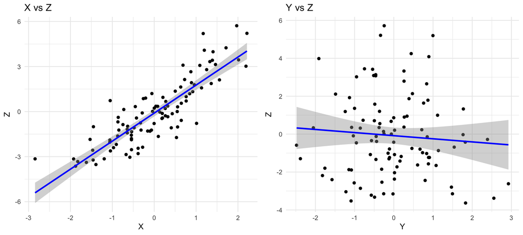

## Model complexity in multiple Regression

```r
fm_low <- lm(Z ~ X, data=d)
fm_high <- lm(Z ~ X + Y, data=d)
```

- Based on the scatter plots above we expect \(Z\) to depend strongly on \(X\) and not at all on \(Y\).
- We therefore expect both the low and high complexity models to fit the data well
- This is because the low complexity model isn’t missing anything important.

## Multiple Regression: Low Complexity

```
##
## Call:
## lm(formula = Z ~ X, data = d)
##
## Residuals:
##     Min      1Q  Median      3Q     Max
## -2.6185 -0.6888 -0.1027  0.5749  3.1159
##
## Coefficients:
##             Estimate Std. Error t value Pr(>|t|)
## (Intercept)  -0.1010     0.1125  -0.898    0.371
## X             1.8657     0.1131  16.499   <2e-16 ***
## ---
## Signif. codes:  0 '***' 0.001 '**' 0.01 '*' 0.05 '.' 0.1 ' ' 1
##
## Residual standard error: 1.125 on 98 degrees of freedom
## Multiple R-squared:  0.7353, Adjusted R-squared:  0.7326
## F-statistic: 272.2 on 1 and 98 DF,  p-value: < 2.2e-16
```

## Multiple Regression: High Complexity

```
##
## Call:
## lm(formula = Z ~ X + Y, data = d)
##
## Residuals:
##     Min      1Q  Median      3Q     Max
## -2.6242 -0.6823 -0.1061  0.5812  3.0773
##
## Coefficients:
##             Estimate Std. Error t value Pr(>|t|)
## (Intercept) -0.10006    0.11307  -0.885    0.378
## X            1.86951    0.11430  16.356   <2e-16 ***
## Y            0.03326    0.10976   0.303    0.763
## ---
## Signif. codes:  0 '***' 0.001 '**' 0.01 '*' 0.05 '.' 0.1 ' ' 1
##
## Residual standard error: 1.13 on 97 degrees of freedom
## Multiple R-squared:  0.7355, Adjusted R-squared:  0.7301
## F-statistic: 134.9 on 2 and 97 DF,  p-value: < 2.2e-16
```

## Penalizing complexity with adjusted \(R^2\)

- The adjusted \(R^2\) applies a penalty for adding predictors:

\[ R^2_{\text{adj}} = 1 - \left(1 - R^2\right) \frac{n - 1}{n - p - 1} \]

- \(R^2\) is the ordinary coefficient of determination.
- \(n\) is the number of observations.
- \(p\) is the number of predictors.
- The term:
- \(\frac{n - 1}{n - p - 1}\) is the **penalty factor** that grows as the number of predictors \(p\) approaches the sample size \(n\).

## How does Adjusted \(R^2\) change with increasing complexity?

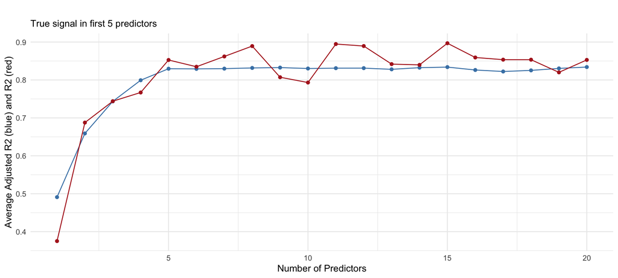

## Identifying the important predictors

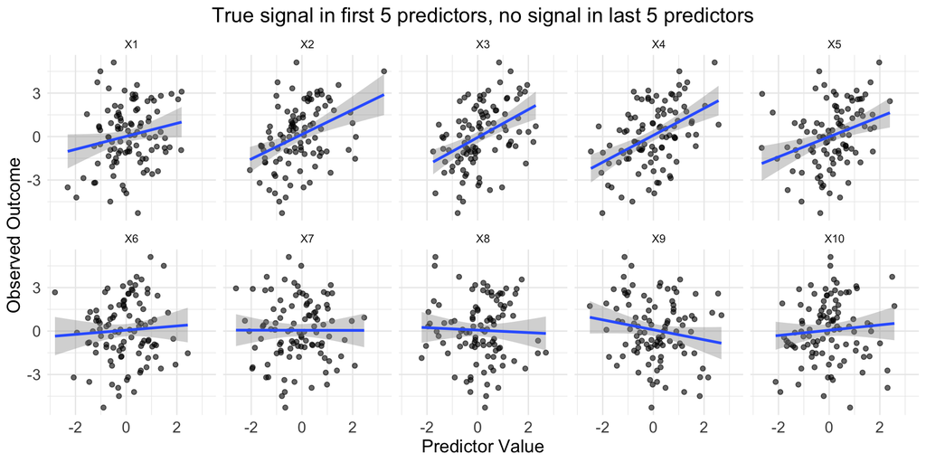

## Adjusted \(R^2\): Strengths and Weaknesses

- Adjusted \(R^2\) partially corrects for adding extra predictors by applying a penalty for model complexity.
- The penalty is relatively mild, and adjusted \(R^2\) can still increase when adding uninformative predictors, especially with small sample sizes.
- Adjusted \(R^2\) is specific to linear regression and may not generalize to other model types.
- More robust model selection tools (like AIC and BIC) incorporate likelihood-based comparisons and work across a wider range of models.